# Data Structures and Groupby

Author

Professor Rachel Brown

Published

September 23, 2025

# Python Data Structures

```python
# import libraries
import numpy as np
import pandas as pd
import matplotlib.pyplot as plt
import seaborn as sns
```

## Lists

**Description:** Ordered, mutable collections that can store different data types

**Examples:** Store measurement values, feature names, or analysis results

```python
# temperature readings from weather stations
temps = [23.5, 25.1, 22.8, 24.9, 26.2]
station_names = ['Downtown','Airport','Harbor','University','Industrial']

# add new reading
temps.append(27.1) # single item
temps.extend([25.5, 24.8, 17.9, 20.2])

# accessing and slicing
recent_temps = temps[-3:] # last 3 readings (start at third from end, go to end)

# list COMPREHENSION
high_temps = [t for t in temps if t > 25] # get temps greater than 25

# print format strings
print(f"avg temp: {sum(temps)/len(temps):.2f} deg C")
```

```
avg temp: 23.80 deg C
```

## Dictionaries

**Description:** Key-value pairs for structured data storage

**Examples:** Store metadata, configuration parameters, or structured datasets

```python
# weather station metadata
station_data = {
    'station_id': 'WS001',
    'location': {
        'lat': 40.75,
        'long': -73.98
    },
    'elevation': 15.2,
    'sensors': ['temperature', 'humidity', 'pressure'],
    'active': True
}

print(station_data)

# coords = station_data['location']
# print(coords)

# sensor_count = len(station_data)
# print(f'station has {sensor_count} sensors')

weather_stations = {
    'WS001' : {'temp': 25.1, 'humidity': 65},
    'WS002' : {'temp': 23.8, 'humidity': 72},
    'WS003' : {'temp': 26.4, 'humidity': 58},
}

print(weather_stations.keys())
print(weather_stations.values())

# average temp
avg_temp = sum(data['temp'] for data in weather_stations.values())/len(weather_stations.values())
print(f"average temp: {avg_temp:.2f}")
```

```
{'station_id': 'WS001', 'location': {'lat': 40.75, 'long': -73.98}, 'elevation': 15.2, 'sensors': ['temperature', 'humidity', 'pressure'], 'active': True}
dict_keys(['WS001', 'WS002', 'WS003'])
dict_values([{'temp': 25.1, 'humidity': 65}, {'temp': 23.8, 'humidity': 72}, {'temp': 26.4, 'humidity': 58}])
average temp: 25.10
```

## Tuples

**Description:** Ordered, immutable collections for fixed data

**Examples:** Coordinates, RGB values, or database records

```python
# GPS coordinates
station_locations = [
    ('Downtown', 40.75, -73.98),
    ('Airport', 40.64, -73.77),
    ('Harbor', 40.68, -74.04)
]

# unpacking values
def calculate_distance(coord1, coord2):
    _, lat1, long1 = coord1 # amount of variables MUST MATCH tuple
    _, lat2, long2 = coord2

    dist = ((lat2 - lat1)**2 + (long2 - long1)**2)**0.5
    return dist

print("distance between Downtown and Airport:")
print(calculate_distance(station_locations[0], station_locations[1]))
```

```
distance between Downtown and Airport:
0.23706539182260075
```

## Sets

**Description:** Unordered collections of unique elements

**Examples:** Finding unique values, set operations on categories

```python
# unique weather conditions
conditions_day1 = {'sunny', 'cloudy', 'windy'}
conditions_day2 = {'sunny', 'cloudy', 'rainy'}
conditions_day3 = {'sunny', 'clear', 'dry'}

# set operations
# or
all_conditions = conditions_day1 | conditions_day2 | conditions_day3
print(all_conditions)

# and
common_conditions = conditions_day1 & conditions_day2
print(common_conditions)

# minus
unique_day1 = conditions_day1 - conditions_day2 - conditions_day3
print(unique_day1)

# finding unique sensors across stations
sensors_station1 = {'temperature', 'humidity', 'pressure'}
sensors_station2 = {'temperature', 'wind_speed', 'pressure'}

all_sensors = sensors_station1 | sensors_station2
print(all_sensors)
```

```
{'rainy', 'clear', 'sunny', 'windy', 'cloudy', 'dry'}
{'cloudy', 'sunny'}
{'windy'}
{'wind_speed', 'temperature', 'humidity', 'pressure'}
```

## Combined Example

This database entry combines all the data structures we’ve talked about so far. Label each part of the database entry with the data structure that it uses.

```python
weather_data = {
    'stations': [
        ('WS001', 'Downtown', [25.1, 24.8, 26.2]),
        ('WS002', 'Airport', [23.5, 24.1, 25.0])
    ],
    'conditions': {'sunny', 'cloudy', 'rainy'},
    'metadata': {
        'collection_date': '2024',
        'units': 'celsius'}
}
```

# Arrays and DataFrames

## Review of Numpy Arrays

**Description:** Efficient numerical arrays with vectorized operations

```python
# Setup: converting lists to arrays for efficient computation
temperatures_list = [23.5, 25.1, 22.8, 24.9, 26.2, 27.1, 25.5, 24.8]
temperatures_array = np.array(temperatures_list)

# Multi-dimensional data: multiple sensors over time
sensor_data = np.array([
    [23.5, 65, 1013.2],  # temp, humidity, pressure
    [25.1, 72, 1012.8],
    [22.8, 58, 1014.1],
    [24.9, 69, 1013.5]
])

# Array properties
print(f"Shape: {sensor_data.shape}")        # 4 3
print(f"Data type: {sensor_data.dtype}")    # float
print(f"Dimensions: {sensor_data.ndim}")    # 2
```

```
Shape: (4, 3)
Data type: float64
Dimensions: 2
```

```python
# vectorized operations
temps_f = temperatures_array * 9/5 + 32
print("temps in F:", temps_f)

normalized_temps = (temperatures_array - np.mean(temperatures_array)) / np.std(temperatures_array)
print("normalized temps:", normalized_temps)

temp_stats = {
    'mean': np.mean(temperatures_array),
    'median': np.median(temperatures_array),
}

daily_averages = np.mean(sensor_data, axis=1)
print("daily averages:", daily_averages)

# boolean indexing
high_temp_days = sensor_data[sensor_data[:,0] > 24]  # days with temp > 24
print(high_temp_days)
```

```
temps in F: [74.3  77.18 73.04 76.82 79.16 80.78 77.9  76.64]
normalized temps: [-1.1558847   0.08741985 -1.69983044 -0.06799322  0.94219173  1.64155054
  0.39824599 -0.14569975]
daily averages: [367.23333333 369.96666667 364.96666667 369.13333333]
[[  25.1   72.  1012.8]
 [  24.9   69.  1013.5]]
```

## Review of DataFrames

**Description:** Labeled data structures for structured data analysis

```python
# Setup: creating a DataFrame from dictionary
weather_df = pd.DataFrame({
    'date': pd.date_range('2024-03-01', periods=10),
    'temperature': [23.5, 25.1, 22.8, 24.9, 26.2, 27.1, 25.5, 24.8, 23.9, 25.7],
    'humidity': [65, 72, 58, 69, 74, 68, 71, 67, 63, 70],
    'pressure': [1013.2, 1012.8, 1014.1, 1013.5, 1012.3, 1011.9, 1013.8, 1014.2, 1013.9, 1012.5],
    'station': ['Downtown', 'Downtown', 'Airport', 'Downtown', 'Harbor',
                'Airport', 'Harbor', 'Downtown', 'Airport', 'Harbor']
})
```

```python
print(weather_df.head(), '\n')
print(weather_df.describe(), '\n')
print(weather_df.info(), '\n')

# indexing and selection
downtown_data = weather_df[weather_df['station'] == 'Downtown']
temp_humidity = weather_df[['temperature', 'humidity']]
recent_data = weather_df.iloc[-3:]
```

```
        date  temperature  humidity  pressure   station
0 2024-03-01         23.5        65    1013.2  Downtown
1 2024-03-02         25.1        72    1012.8  Downtown
2 2024-03-03         22.8        58    1014.1   Airport
3 2024-03-04         24.9        69    1013.5  Downtown
4 2024-03-05         26.2        74    1012.3    Harbor

                      date  temperature   humidity     pressure
count                   10    10.000000  10.000000    10.000000
mean   2024-03-05 12:00:00    24.950000  67.700000  1013.220000
min    2024-03-01 00:00:00    22.800000  58.000000  1011.900000
25%    2024-03-03 06:00:00    24.125000  65.500000  1012.575000
50%    2024-03-05 12:00:00    25.000000  68.500000  1013.350000
75%    2024-03-07 18:00:00    25.650000  70.750000  1013.875000
max    2024-03-10 00:00:00    27.100000  74.000000  1014.200000
std                    NaN     1.287763   4.715224     0.809389

<class 'pandas.core.frame.DataFrame'>
RangeIndex: 10 entries, 0 to 9
Data columns (total 5 columns):
 #   Column       Non-Null Count  Dtype
---  ------       --------------  -----
 0   date         10 non-null     datetime64[ns]
 1   temperature  10 non-null     float64
 2   humidity     10 non-null     int64
 3   pressure     10 non-null     float64
 4   station      10 non-null     object
dtypes: datetime64[ns](1), float64(2), int64(1), object(1)
memory usage: 532.0+ bytes
None
```

# The Pandas Groupby Function

First, the simplest implementation of groupby! You always need at least three ingredients:

1. One or more variables to group by
2. One or more variables to aggregate on
3. One or more functions to apply for aggregation
   - aggregation (summary statistic)
   - transformation
   - filtration

## Basic Groupby

```python
# group by station and calculate mean temp
avg_temp_station = weather_df.groupby('station')['temperature'].mean()

# equivalent:
# avg_temp_station = weather_df.groupby('station')['temperature'].agg('mean')
```

We can also use multiple aggregation functions.

```python
# multiple agg functions to one column
temp_stats = weather_df.groupby('station')['temperature'].agg(['mean', 'min', 'max', 'count'])
# index becomes names of station, columns become mean, min, max, and count

print("Temp stats by station:")
print(temp_stats)
```

```
Temp stats by station:
            mean   min   max  count
station
Airport   24.600  22.8  27.1      3
Downtown  24.575  23.5  25.1      4
Harbor    25.800  25.5  26.2      3
```

Or the same aggregation to multiple columns.

```python
# apply same agg to multiple columns
multi_column_names = weather_df.groupby('station')[['temperature', 'humidity', 'pressure']].mean()
print(multi_column_names.round(2))
```

```
          temperature  humidity  pressure
station
Airport         24.60     63.00   1013.30
Downtown        24.58     68.25   1013.42
Harbor          25.80     71.67   1012.87
```

## Specialized Groupby Output

We can also customize the output of Groupby/Aggregate in a couple ways

```python
# apply different agg functions to different columns
mixed_agg = weather_df.groupby('station').agg({
    'temperature': 'mean',
    'humidity': 'max',
    'pressure': 'min',
    'date': 'count'
})

print(mixed_agg.round(2))
print('\n')

simple_custom = weather_df.groupby('station').agg(
    avg_temperature = ('temperature', 'mean'),
    max_humidity = ('humidity', 'max'),
    reading_count = ('temperature', 'count')
)

print(simple_custom)
```

```
          temperature  humidity  pressure  date
station
Airport         24.60        68    1011.9     3
Downtown        24.58        72    1012.8     4
Harbor          25.80        74    1012.3     3


          avg_temperature  max_humidity  reading_count
station
Airport            24.600            68              3
Downtown           24.575            72              4
Harbor             25.800            74              3
```

# In Class Coding Exercise

Today we will be continuing our weather theme by making use of a synthetic dataset called **Weather Data** published by (Prasad Patil on Kaggle)[https://www.kaggle.com/datasets/prasad22/weather-data]. The csv file has been provided to you, please put it in your “datasets” folder and use the appropriate path to access it.

## Instructions

In the original dataset there is only one categorical variable, `Location`. However, we also have a timestamp with a date, so we can separate out that information into columns for `year`, `month`, `day`, and `hour`, and group our data by those variables as well. This makes sense because there are likely to be interesting weather data correlations within these variables.

### Part 1

Before starting the grouping questions, create the additional variables you need by following these steps:

- Load the dataset
- Use the `pd.to_datetime` function to conver the `Date_Time` column to a datetime data type ((documentation here)[https://pandas.pydata.org/docs/reference/api/pandas.to_datetime.html])
- Overwrite the imported dataset with a new dataset using the `.assign()` function ((docs)[https://pandas.pydata.org/docs/reference/api/pandas.DataFrame.assign.html]) to create additional variables for the year, month, day, and hour. An example of how to get just the year would be `df['Date_Time'].dt.year`.
- Print the first five rows (head()) of the new dataframe to check your work before continuing!

### Part 2

For the groupby practice, create the following outputs:

1. Average temperature by location
2. Average humidity, precipitation, and wind speed by location
3. The min, max, mean, and median precipitation by month
4. A DataFrame grouped by hour with the mean and median for both precipitation and wind speed (provide names for the output variables like “median_precipitation”)
5. Number of observations with a temperature over 30 degrees Celcius for each location (**Hint:** think about the best order of operations for this one!)
6. Min, max, and median temperature and precipitation for each month

### Part 3

Lastly, use the data structure you created in question #6 to generate an appropriate visualization of that data.

## Answers

Your code and answers go here!

### 1

```python
# import libraries
import numpy as np
import pandas as pd
import matplotlib as mpl
import matplotlib.pyplot as plt
import seaborn as sns

# import dataset
df = pd.read_csv('./../../datasets/weather_data.csv')

df['Date_Time'] = pd.to_datetime(df['Date_Time'])

df = df.assign(
    year = df['Date_Time'].dt.year,
    month = df['Date_Time'].dt.month,
    day = df['Date_Time'].dt.day,
    hour = df['Date_Time'].dt.hour
)

print(df.head())
```

```
       Location           Date_Time  Temperature_C  Humidity_pct  \
0     San Diego 2024-01-14 21:12:46      10.683001     41.195754
1     San Diego 2024-05-17 15:22:10       8.734140     58.319107
2     San Diego 2024-05-11 09:30:59      11.632436     38.820175
3  Philadelphia 2024-02-26 17:32:39      -8.628976     54.074474
4   San Antonio 2024-04-29 13:23:51      39.808213     72.899908

   Precipitation_mm  Wind_Speed_kmh  year  month  day  hour
0          4.020119        8.233540  2024      1   14    21
1          9.111623       27.715161  2024      5   17    15
2          4.607511       28.732951  2024      5   11     9
3          3.183720       26.367303  2024      2   26    17
4          9.598282       29.898622  2024      4   29    13
```

### 2

1. Average temperature by location

```python
avg_temp_location = df.groupby('Location')['Temperature_C'].mean()
print(avg_temp_location)
```

```
Location
Chicago         15.009208
Dallas          15.009097
Houston         14.942985
Los Angeles     15.081063
New York        15.013389
Philadelphia    15.035892
Phoenix         12.792479
San Antonio     15.027761
San Diego       14.933539
San Jose        14.956108
Name: Temperature_C, dtype: float64
```

```python
avg_by_location = df.groupby('Location')[['Temperature_C', 'Humidity_pct', 'Wind_Speed_kmh']].mean()
print(avg_by_location)
```

```
              Temperature_C  Humidity_pct  Wind_Speed_kmh
Location
Chicago           15.009208     60.088798       14.999501
Dallas            15.009097     59.959900       15.022001
Houston           14.942985     59.967598       14.989935
Los Angeles       15.081063     60.072151       15.035120
New York          15.013389     60.044688       14.989398
Philadelphia      15.035892     60.044902       14.990663
Phoenix           12.792479     60.048643       14.983904
San Antonio       15.027761     59.932798       14.956579
San Diego         14.933539     60.072074       15.037633
San Jose          14.956108     59.986630       14.971369
```

```python
precip_month = df.groupby('month')['Precipitation_mm'].mean()
print(precip_month)
```

```
month
1    5.260547
2    5.245150
3    4.996019
4    4.999556
5    5.010418
Name: Precipitation_mm, dtype: float64
```

4. A DataFrame grouped by hour with the mean and median for both precipitation and wind speed (provide names for the output variables like “median_precipitation”)

```python
precip_wind = df.groupby('hour').agg(
    mean_precipiation = ('Precipitation_mm', 'mean'),
    median_precipiation = ('Precipitation_mm', 'median'),
    mean_wind = ('Wind_Speed_kmh', 'mean'),
    median_wind = ('Wind_Speed_kmh', 'median'),
)

print(precip_wind)
```

```
      mean_precipiation  median_precipiation  mean_wind  median_wind
hour
0              5.099014             5.109721  14.929012    14.918861
1              5.101507             5.095127  14.955447    14.949719
2              5.091484             5.073844  15.028387    15.064629
3              5.111792             5.113347  15.010294    14.921660
4              5.120125             5.149784  14.930876    14.898832
5              5.102140             5.093127  15.020795    15.024693
6              5.113841             5.096676  15.003237    14.920052
7              5.099622             5.097921  14.955902    14.985897
8              5.122042             5.107261  15.033033    15.082648
9              5.134675             5.161147  15.026952    15.069089
10             5.115746             5.134473  15.011182    15.028620
11             5.123923             5.114329  15.053539    14.966923
12             5.133904             5.144278  15.035538    15.066975
13             5.123277             5.124837  15.041808    15.095233
14             5.113310             5.137204  14.991518    15.024876
15             5.098353             5.101663  15.042730    15.136455
16             5.123473             5.138649  14.943132    14.883134
17             5.070889             5.047858  15.010571    15.061704
18             5.126762             5.133662  14.998227    14.981446
19             5.088549             5.079192  14.992502    14.982322
20             5.093801             5.066953  15.025172    14.985149
21             5.107528             5.112345  14.952191    14.915319
22             5.106357             5.095005  14.970230    14.979472
23             5.108888             5.107175  14.979447    14.934234
```

5. Number of observations with a temperature over 30 degrees Celcius for each location (**Hint:** think about the best order of operations for this one!)

```python
temp_df = df[df['Temperature_C'] > 30]
high_temp_location = temp_df.groupby('Location')['Temperature_C'].count()

print(high_temp_location)
```

```
Location
Chicago         20089
Dallas          19999
Houston         19806
Los Angeles     20231
New York        19841
Philadelphia    20054
Phoenix         15610
San Antonio     19934
San Diego       19724
San Jose        19632
Name: Temperature_C, dtype: int64
```

6. Min, max, and median temperature and precipitation for each month

```python
month_temp_precip = df.groupby('month').agg(
    min_temp = ('Temperature_C', 'min'),
    max_temp = ('Temperature_C', 'max'),
    med_temp = ('Temperature_C', 'median'),
    min_prec = ('Precipitation_mm', 'min'),
    max_prec = ('Precipitation_mm', 'max'),
    med_prec = ('Precipitation_mm', 'median'),
)

print(month_temp_precip)
```

```
        min_temp   max_temp   med_temp  min_prec   max_prec  med_prec
month
1     -19.969311  39.999692  14.411772  0.000167  14.971583  5.258245
2     -19.847193  39.998693  14.520044  0.000029  14.896195  5.240810
3      -9.999966  39.999015  15.030727  0.000010   9.999832  4.989908
4      -9.999964  39.999670  15.020363  0.000009   9.999944  5.004108
5      -9.999913  39.999801  15.003318  0.000089   9.999873  5.020153
```

### 3

Temperature and Precipiation by Month

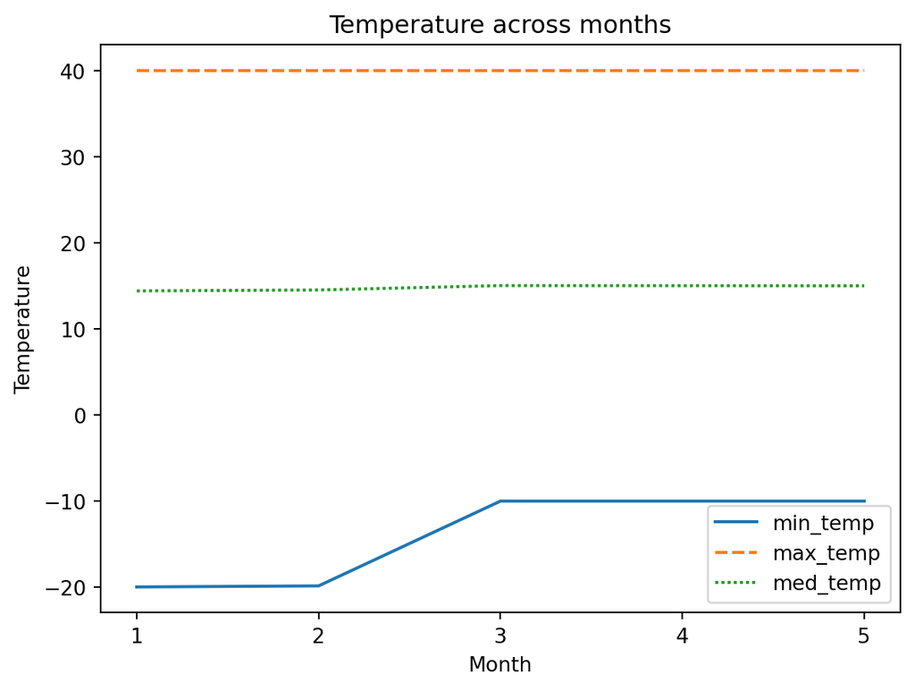

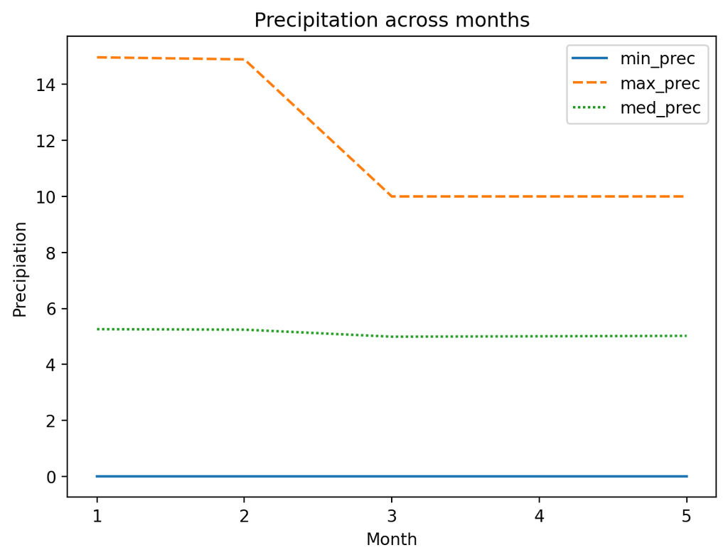

```python
temp_df = month_temp_precip[['min_temp', 'max_temp', 'med_temp']]
precip_df = month_temp_precip[['min_prec', 'max_prec', 'med_prec']]

g1 = sns.lineplot(temp_df)
g1.set_xlabel("Month")
g1.set_ylabel("Temperature")
plt.title("Temperature across months")
plt.xticks(range(1,6))
plt.show()

g2 = sns.lineplot(precip_df)
g2.set_xlabel("Month")
g2.set_ylabel("Precipiation")
plt.title("Precipitation across months")
plt.xticks(range(1,6))
plt.show()
```